# Tema 9: Emparejamientos en redes

Optimización y Análisis de Redes

DSLAB

2026-10-12

## Objetivos de aprendizaje

1. **Definir** y **clasificar** emparejamientos maximales, de máximo cardinal y perfectos.
2. **Demostrar** y **aplicar** el Teorema de Berge mediante cadenas incrementales.
3. **Analizar** la descomposición del grafo diferencia simétrica $G' = (V, K_1 \bigtriangleup K_2)$.
4. **Construir** árboles y bosques alternantes con niveles $Y^0$ e $Y^1$.
5. **Ejecutar** el algoritmo de contracción y descompresión de flores de Edmonds.
6. **Demostrar** y **aplicar** el Teorema de Dualidad de Gallai ($|K_0| + |F_0| = |V|$).
7. **Formular** y **resolver** emparejamientos de máximo peso por costes reducidos.

# Fundamentos y conceptos de emparejamiento

## Asignación de tripulaciones de la RAF (1940)

- **Contexto de la Batalla de Inglaterra (1940)**:
  - Formar parejas de dos pilotos para cazas biplaza de combate.
- **Restricción de comunicación lingüística**:
  - Ambos aviadores deben dominar al menos un idioma común para coordinar maniobras en cabina.
- **Objetivo de optimización**:
  - Maximizar el número total de aviones biplaza que pueden despegar simultáneamente.
- **Competencias lingüísticas (7 aviadores)**:
  - **$P$**, **$P'$**: Solo polaco.
  - **$PI$**: Polaco e inglés.
  - **$I$**: Solo inglés.
  - **$A$**: Solo alemán.
  - **$AI$**: Alemán e inglés.
  - **$FI$**: Francés e inglés.

## Ejemplo RAF: Construcción del grafo de compatibilidad

- **Grafo simple no dirigido $G = (V, E)$**:
  - $V = \{P, PI, P', I, A, AI, FI\}$ (los 7 aviadores disponibles).
  - Aristas: Existe arista $\{u, v\} \in E$ si los pilotos $u$ y $v$ comparten al menos un idioma.

$$\begin{aligned}
E = \bigl\{ & \{P, PI\}, \, \{P, P'\}, \, \{PI, P'\}, \, \{PI, I\}, \, \{PI, AI\}, \\
& \{PI, FI\}, \, \{I, FI\}, \, \{I, AI\}, \, \{FI, AI\}, \, \{A, AI\} \bigr\}
\end{aligned}$$

- **Cota superior teórica**: Con 7 pilotos, el número máximo de parejas disjuntas es $\lfloor 7/2 \rfloor = 3$.

## Ejemplo RAF: Reasignación de máximo cardinal

- **Reasignación coordinada de parejas**:
  - Deshacer las asignaciones codiciosas para compartir los idiomas puente (polaco e inglés):
    $$K_2 = \bigl\{ \{P, P'\}, \, \{PI, I\}, \, \{AI, FI\} \bigr\} \quad (|K_2| = 3)$$
- **Alineación lingüística lograda**:
  - $\{P, P'\}$ se comunican en polaco; $\{PI, I\}$ y $\{AI, FI\}$ se comunican en inglés.
- **Resultado óptimo global**:
  - Aviones biplaza operativos: **3**. Piloto libre: solo **1** ($A$).
  - Se alcanza la cota teórica superior $\lfloor 7/2 \rfloor = 3$, demostrando que $K_2$ es de **máximo cardinal**.

## Ejemplo RAF: Comparación gráfica de soluciones

[figure not shown]

## Definición: Emparejamiento en un grafo

**Emparejamiento en un grafo**

Dado un grafo no dirigido simple $G = (V, E)$, un **emparejamiento** (*matching*) es un subconjunto de aristas $K \subseteq E$ tal que ninguna pareja de aristas comparte vértices:

$$e_1 \cap e_2 = \emptyset, \quad \forall e_1, e_2 \in K, \; e_1 \neq e_2$$

- **Grado en $G_K = (V, K)$**: $\operatorname{gr}_{G_K}(v) \le 1, \; \forall v \in V$.
- **Independencia**: Las aristas de $K$ son mutuamente disjuntas en sus extremos.

## Formulación algebraica y de programación lineal

- **Representación mediante vector binario**:
  - $\mathbf{x} \in \{0, 1\}^{|E|}$, donde $x_e = 1$ si $e \in K$, y $x_e = 0$ en caso contrario.
- **Restricción de no adyacencia nodal**:
  $$\sum_{e \in \delta(v)} x_e \le 1, \quad \forall v \in V$$
- **Modelo en Programación Lineal Entera (PLE)**:
  $$\max \left\{ \sum_{e \in E} x_e : \sum_{e \in \delta(v)} x_e \le 1 \; \forall v \in V, \; x_e \in \{0, 1\} \; \forall e \in E \right\}$$

## Hereditariedad de los emparejamientos

**Hereditariedad de los emparejamientos**

Dado un grafo $G = (V, E)$ y un emparejamiento $K \subseteq E$, cualquier subconjunto $K' \subseteq K$ es también un emparejamiento de $G$.

- **Estructura de complejo simplicial**:
  - La familia $\mathcal{I}$ de todos los emparejamientos de $G$ forma un sistema de independencia.
  - El conjunto vacío $\emptyset \in \mathcal{I}$ y cada arista individual $\{e\} \in \mathcal{I}$.
- **Espacio factible**: Las soluciones factibles son subconjuntos independientes de aristas.

## Definición: Problema de emparejamiento de máximo cardinal

**Problema de emparejamiento de máximo cardinal**

Dado un grafo no dirigido $G = (V, E)$, el **problema de emparejamiento de máximo cardinal** consiste en determinar un emparejamiento $K \subseteq E$ que maximice $|K|$.

- **Objetivo de optimización global**: Hallar $K^* \in \mathcal{I}$ tal que $|K^*| = \max_{K \in \mathcal{I}} |K|$.
- **Cota superior general**: $|K| \le \lfloor |V| / 2 \rfloor$.

## Definición: Vértices saturados y vértices expuestos

**Vértices saturados y vértices expuestos**

Dado un grafo $G = (V, E)$ y un emparejamiento $K \subseteq E$:

- Un vértice $x \in V$ está **saturado** por $K$ si existe alguna arista $\{x, y\} \in K$ incidente en $x$.
- Un vértice $x \in V$ está **expuesto** (o libre) si ninguna arista de $K$ incide en $x$.
- **Balance nodal**: Vértices saturados = $2|K|$; Vértices expuestos = $|V| - 2|K|$.

## Condición de parada por cardinalidad de expuestos

**Condición de parada por cardinalidad de expuestos**

Dado un grafo $G = (V, E)$ con $n = |V|$ vértices y un emparejamiento $K \subseteq E$, si el número de vértices no saturados (expuestos) es $0$ o $1$, entonces $K$ es un **emparejamiento de máximo cardinal**.

- **Criterio determinista**:
  - Añadir una arista disjunta exige disponer de al menos $2$ vértices libres disponibles.
  - Con $\le 1$ vértice libre, no es posible añadir ninguna arista más.

## Emparejamiento maximal vs. Máximo cardinal

- **Emparejamiento maximal (por inclusión)**:
  - No se le puede añadir ninguna arista más de $E$ de forma directa:
    $$\nexists e \in E \setminus K : K \cup \{e\} \in \mathcal{I}$$
  - Es un óptimo local alcanzado por algoritmos codiciosos (*greedy*).
- **Emparejamiento de máximo cardinal**:
  - Alcanza el máximo valor absoluto de $|K|$ entre todos los emparejamientos:
    $$|K^*| \ge |K|, \quad \forall K \in \mathcal{I}$$
  - Exige **reorganizar y reasignar parejas** a lo largo del grafo.

## Definición: Emparejamiento perfecto

**Emparejamiento perfecto (1-factor)**

Dado un grafo $G = (V, E)$ con $n = |V|$ vértices, un emparejamiento $K \subseteq E$ se dice **perfecto** (o 1-factor) si satura a todos los vértices del grafo ($|V| - 2|K| = 0$):

$$|K| = \frac{n}{2}$$

- **Condición de paridad**: Requiere obligatoriamente que el orden $n = |V|$ sea un número **par**.

# Resolución mediante cadenas alternantes e incrementales

## Cadenas alternantes, cadenas incrementales y transferencias

- **Principio de mejora local iterativa**:
  - Modificar el emparejamiento actual intercambiando asignaciones para aumentar su tamaño.
- **Reasignación en cascada**:
  - Alternar aristas no emparejadas con emparejadas para reajustar aristas adyacentes.
- **Herramienta combinatoria**:
  - Las **cadenas alternantes** actúan como conductos de reasignación de parejas.

## Definición: Cadena alternante e incremental

**Cadena alternante e incremental**

Dado un grafo $G = (V, E)$ y un emparejamiento $K \subseteq E$:

- Una **cadena alternante** es una cadena simple $\mu = (v_1, v_2, \dots, v_k)$ cuyas aristas pertenecen y no pertenecen alternativamente a $K$ (alternan entre $K$ y $E \setminus K$).
- Una **cadena incremental** (o de aumento) $\mu[x, y]$ con $x \neq y$ es una cadena alternante cuyos dos vértices extremos $x$ e $y$ son **vértices expuestos** respecto de $K$.

## Propiedades algebraicas de las cadenas incrementales

- **1. Longitud impar de aristas**:
  - Toda cadena incremental contiene un **número impar de aristas** ($2k + 1$).
  - Sus aristas primera y última pertenecen obligatoriamente a $E \setminus K$.
- **2. Balance asimétrico de aristas**:
  - Exactamente $k + 1$ aristas pertenecen a $E \setminus K$.
  - Exactamente $k$ aristas pertenecen a $K$.
    $$|\mu \setminus K| = |\mu \cap K| + 1$$

## Definición: Operación de transferencia

**Operación de transferencia**

Dado un emparejamiento $K$ y una cadena incremental $\mu[x, y]$, la **transferencia** sustituye las aristas de $\mu \cap K$ por las de $\mu \setminus K$:

$$K' = K \bigtriangleup \mu[x, y] = (K \setminus \mu) \cup (\mu \setminus K)$$

El emparejamiento resultante satisface estrictamente:
$$|K'| = |K| + 1$$

## Ejemplo Transferencia: Grafo de 6 nodos y estado inicial

- **Grafo simple $G=(V, E)$**:
  - Vértices: $V = \{1, 2, 3, 4, 5, 6\}$ (6 nodos).
  - Emparejamiento inicial: $K = \bigl\{ \{2,3\}, \, \{5,6\} \bigr\}$ ($|K| = 2$).
- **Estado de saturación nodal**:
  - Vértices saturados ($sat = 1$): $\{2, 3, 5, 6\}$.
  - Vértices expuestos ($sat = 0$, libres): $\{1, 4\}$.
- **Objetivo algorítmico**:
  - Buscar un camino alternante que conecte los dos extremos libres $1$ y $4$ para aumentar el tamaño del emparejamiento.

## Ejemplo Transferencia: Detección de la cadena incremental

- **Cadena alternante entre vértices libres 1 y 4**:
  $$\mu = (1, 2, 3, 4)$$
- **Análisis de alternancia de aristas**:
  - $\{1, 2\} \in E \setminus K$ (no pertenece a $K$).
  - $\{2, 3\} \in K$ (pertenece a $K$).
  - $\{3, 4\} \in E \setminus K$ (no pertenece a $K$).
- **Propiedad fundamental de aumento**:
  - Longitud $3$ (impar): contiene 2 aristas fuera de $K$ frente a 1 dentro de $K$.
  - Al permutar la pertenencia de las aristas, el balance neto aportará $+1$ arista al emparejamiento.

## Ejemplo Transferencia: Ejecución y emparejamiento perfecto

- **Diferencia simétrica $K' = K \bigtriangleup \mu$**:
  - Sale de $K$: $\{2, 3\}$. Entran a $K$: $\{1, 2\}$ y $\{3, 4\}$. Permanece: $\{5, 6\}$.
    $$K' = \bigl\{ \{1,2\}, \, \{3,4\}, \, \{5,6\} \bigr\} \quad (|K'| = 3, \text{perfecto})$$

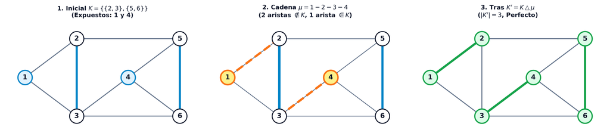

## Estructura del grafo diferencia simétrica

**Lema: Estructura del grafo diferencia simétrica**

Dados dos emparejamientos cualesquiera $K_1$ y $K_2$ en un grafo simple $G = (V, E)$, el subgrafo generado por la diferencia simétrica $G' = (V, K_1 \bigtriangleup K_2)$ está compuesto exclusivamente por:

1. **Vértices aislados** (grado $0$).
2. **Ciclos elementales alternantes** de longitud estrictamente par.
3. **Cadenas elementales alternantes** de longitud par o impar.

## Análisis de grados en la diferencia simétrica

- **Grados nodales en $G' = (V, K_1 \bigtriangleup K_2)$**:
  - **$d_{G'}(v) = 0$**: Vértice no saturado por $K_1$ ni $K_2$, o saturado por la misma arista ($e \in K_1 \cap K_2$).
  - **$d_{G'}(v) = 1$**: Vértice saturado solo por uno de los dos emparejamientos (**extremos de cadenas**).
  - **$d_{G'}(v) = 2$**: Vértice saturado por aristas distintas en $K_1$ y $K_2$.
- **Consecuencia topológica**: $\Delta(G') \le 2$, impidiendo ramificaciones de grado $\ge 3$.

## Componentes conexas en la diferencia simétrica

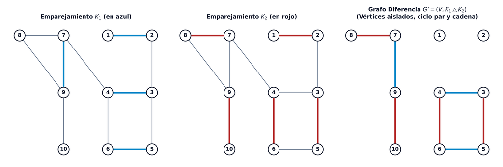

- Los ciclos deben tener longitud par obligatoria para alternar entre $K_1$ y $K_2$.

## Ejemplo Diferencia Simétrica: Grafo bipartito de 10 vértices

- **Estructura bipartita**:
  - Conjunto superior: $\{1, 2, 3, 4, 5\}$; Conjunto inferior: $\{6, 7, 8, 9, 10\}$.
- **Emparejamientos a comparar**:
  - **$K_1$ (azul, 3 aristas)**: $K_1 = \bigl\{ \{2,7\}, \, \{3,8\}, \, \{5,10\} \bigr\}$.
  - **$K_2$ (rojo, 2 aristas)**: $K_2 = \bigl\{ \{3,10\}, \, \{5,8\} \bigr\}$.
- **Objetivo de análisis**:
  - Superponer $K_1$ y $K_2$ en el subgrafo de discrepancias $G' = (V, K_1 \bigtriangleup K_2)$ y clasificar sus componentes conexas.

## Ejemplo Diferencia Simétrica: Descomposición de componentes

- **Componentes en $G' = (V, K_1 \bigtriangleup K_2)$**:
  1. **Ciclo alternante par**: $(3, 8, 5, 10, 3)$ de longitud 4 (2 aristas azules de $K_1$ y 2 rojas de $K_2$).
  2. **Cadena alternante**: $(2, 7)$ de longitud 1 (arista de $K_1$).
  3. **Vértices aislados**: $1, 4, 6, 9$.

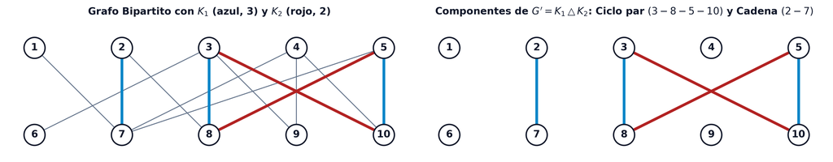

## Teorema de caracterización de Berge

**Caracterización de Berge (1957)**

Dado un grafo $G = (V, E)$, un emparejamiento $K \subseteq E$ es de **máximo cardinal** si y solo si el grafo $G$ **no contiene ninguna cadena incremental** con respecto a $K$.

- **Condición necesaria y suficiente**:
  - Si existe cadena incremental $\mu$, la transferencia $K \bigtriangleup \mu$ aumenta el cardinal.
  - Si no existen cadenas incrementales, la descomposición de $K \bigtriangleup K^*$ certifica $|K| = |K^*|$.

## Interpretación y analogías del Teorema de Berge

- **Certificado de optimalidad global**:
  - Una condición local determinista (ausencia de cadenas incrementales) certifica la optimalidad global.
- **Analogías fundamentales en Investigación Operativa**:
  - **Ford-Fulkerson (Capítulo 8)**: La ausencia de caminos de aumento en la red residual certifica el flujo máximo.
  - **Método del Símplex (Capítulo 3)**: La no negatividad de los costes reducidos certifica el óptimo lineal.

# Algoritmo del árbol alternante y contracción de flores (Edmonds)

## Variable indicadora de saturación y estructura de K

- **Variable indicadora de saturación $sat(x)$**:
  $$sat(x) = \begin{cases} 1, & \text{si } x \text{ está saturado por } K \\ 0, & \text{si } x \text{ es un vértice expuesto} \end{cases}$$
- **Bipartición de $G_K = (V, K)$**:
  - El subgrafo parcial formado exclusivamente por las aristas de $K$ es siempre un **grafo bipartito**, pues cada arista forma una componente $K_2$ independiente.

## Definición: Árbol alternante y bosque alternante

**Árbol alternante y bosque alternante**

Dados un grafo $G = (V, E)$ y un emparejamiento $K \subseteq E$, un **árbol alternante** es un subgrafo parcial $H = (W, T)$ que satisface:

1. $H$ es un árbol (conexo y sin ciclos).
2. Existe un único vértice distinguido $r \in W$ (**raíz expuesta**, $sat(r) = 0$).
3. Cualquier cadena en $H$ que une un vértice $w \in W$ con la raíz $r$ es una **cadena alternante**.

Un conjunto de árboles alternantes disjuntos cuyas raíces son vértices expuestos forma un **bosque alternante** $\{H(r) : r \in R\}$.

## Gestión computacional: Vector de antecesores p

- **Caracterización mediante el vector de padres $\mathbf{p} \in V^n$**:
  - Cada raíz $r \in R$ se identifica por la autorreferencia $p(r) = r$.
  - La única cadena alternante entre cualquier nodo $w$ y su raíz $r$ se recupera encadenando $\mathbf{p}$:
    $$w \longleftrightarrow p(w) \longleftrightarrow p(p(w)) \longleftrightarrow \cdots \longleftrightarrow r$$

## Ejemplo Bosque Alternante: Planteamiento y raíces en 6 nodos

- **Grafo de 6 vértices**:
  - $V = \{1, 2, 3, 4, 5, 6\}$ con aristas $\{\{1,4\}, \{1,5\}, \{1,6\}, \{2,5\}, \{3,5\}\}$.
  - Emparejamiento actual: $K = \bigl\{ \{1,4\}, \, \{2,5\} \bigr\}$ ($|K| = 2$).
- **Raíces expuestas ($sat = 0$)**:
  - $R = \{3, 6\}$. Iniciar dos árboles alternantes independientes: $H(3)$ y $H(6)$.
  - Desde raíz $3$: explorar $\{3,5\} \notin K$ y $\{5,2\} \in K$.
  - Desde raíz $6$: explorar $\{6,1\} \notin K$ y $\{1,4\} \in K$.

## Ejemplo Bosque Alternante: Vector p y Optimalidad

- **Árboles alternantes**: $H(3) = (\{2,3,5\}, \{\{3,5\}, \{2,5\}\})$; $H(6) = (\{1,4,6\}, \{\{6,1\}, \{1,4\}\})$.
- **Vector de padres**: $\mathbf{p}^T = (6, 5, 3, 1, 3, 6)$.
- **Optimalidad**: Al no alcanzarse más nodos libres, por Berge $K$ es de **máximo cardinal** ($|K|=2$).

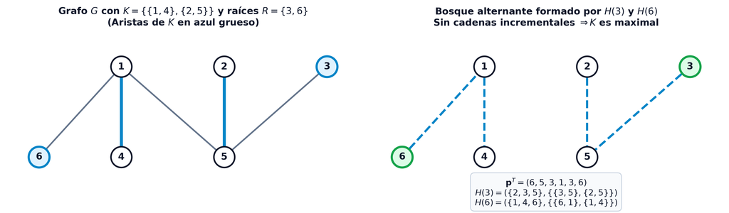

## Ejemplo Árbol 10 Nodos: Planteamiento y exploración desde raíz 1

- **Grafo bipartito con $K_1$ inicial**:
  $$K_1 = \bigl\{ \{2,7\}, \, \{3,8\}, \, \{5,10\} \bigr\} \quad (|K_1| = 3)$$
- **Exploración por niveles desde raíz expuesta $r = 1$ ($sat(1) = 0$)**:
  - $1 \to 7$ ($\notin K$) $\to 2$ ($\in K$).
  - $2 \to 8$ ($\notin K$) $\to 3$ ($\in K$).
  - $3 \to 10$ ($\notin K$) $\to 5$ ($\in K$).
- **Hojas libres alcanzadas desde nodo 3**:
  - $3 \to 6$ ($\notin K$, nodo libre $6$) y $3 \to 9$ ($\notin K$, nodo libre $9$).
  - Se detectan **dos cadenas incrementales disyuntivas** hacia la raíz 1.

## Ejemplo Árbol 10 Nodos: Vector p y Transferencia

- **Vector de padres**: $\mathbf{p}^T = (1, 7, 8, 0, 10, 3, 1, 2, 3, 3)$.
- **Transferencia por nodo 6**: $\mu = (6, 3, 8, 2, 7, 1) \implies K'_1 = \bigl\{ \{6,3\}, \{8,2\}, \{7,1\}, \{5,10\} \bigr\}$ ($|K'_1|=4$).

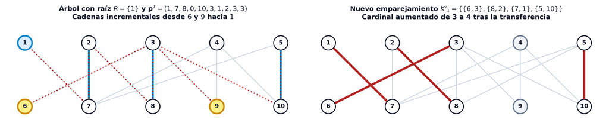

## El desafío de los ciclos impares en grafos generales

- **Grafos bipartitos**:
  - Todos los ciclos tienen longitud par.
  - La búsqueda con árboles alternantes progresa siempre de forma directa hacia nuevos vértices o detecta cadenas incrementales.
- **Grafos generales y ciclos impares**:
  - Los ciclos de longitud impar (**flores** o *blossoms*) introducen una dificultad estructural.
  - Un ciclo impar puede hacer que un nodo sea alcanzable por caminos alternantes pares e impares.

## Propiedad de la flor en ciclos impares

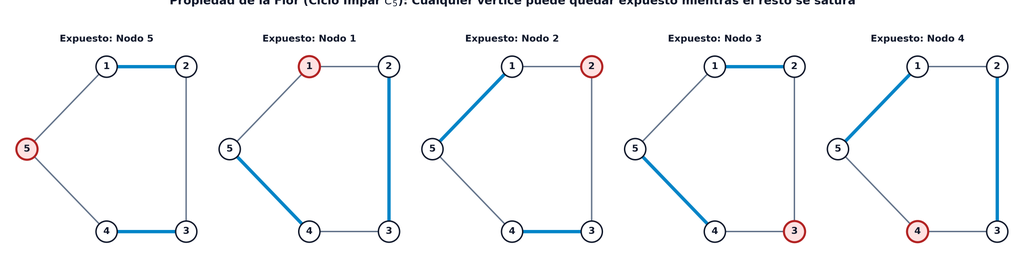

- En un ciclo impar de $2k + 1$ vértices ($C_5$), el emparejamiento maximal satura a $2k$ vértices con $k$ aristas.
- **Propiedad clave**: **Cualquiera de los $2k+1$ vértices del ciclo puede elegirse libremente como el vértice expuesto**.

## Definición: Grafo comprimido G/W

**Contracción de un grafo (Grafo comprimido)**

Dado un grafo no dirigido $G = (V, E)$ y un subconjunto de vértices $W \subset V$ correspondiente a un ciclo impar, se define el **grafo comprimido** $G/W$ como:

$$G/W = \bigl( (V \setminus W) \cup \{w\}, \, E/W \bigr)$$

donde $w$ es un nuevo pseudovértice y $E/W$ reasigna las aristas incidentes en $W$ hacia $w$.

## Teorema: Contracción de ciclos impares de Edmonds

**Contracción de ciclos impares de Edmonds (1965)**

Sea $G = (V, E)$ un grafo, $W \subset V$ un subconjunto de vértices asociado a un ciclo de longitud impar, y sea $K_1$ un emparejamiento en el grafo comprimido $G/W$.

Entonces, existe un emparejamiento $K_W$ en el subgrafo generado por $W$ tal que:

$$K = K_1 \cup K_W$$

es un emparejamiento válido de $G$.

## Reglas operativas de descompresión de flores

- **1. Existencia de vértice expuesto**:
  - Al ser $W$ un ciclo impar, siempre queda exactamente un vértice no saturado en $W$ respecto de $K_W$.
- **2. Libertad de selección**:
  - Siempre es posible elegir de forma determinista qué vértice del ciclo queda no saturado.
- **3. Alineación con la arista exterior**:
  - Si el pseudonodo $w$ está saturado en $K_1$, se deja no saturado en el ciclo el vértice $i \in W$ incidente en la arista exterior que satura a $w$.

## Advertencia: Maximalidad en grafos comprimidos

- **Advertencia teórica**:
  - Que $K_1$ sea **maximal** en $G/W$ no implica necesariamente que $K$ sea de **máximo cardinal** en $G$.
- **Contraejemplo**:
  - Ciclo $\{1, 2, 3\}$ y aristas exteriores $\{ \{1,6\}, \{2,4\}, \{3,5\} \}$.
  - En $G/W$, $K_1 = \bigl\{ \{w, 6\} \bigr\}$ es maximal pero produce $|K| = 2$ en $G$, cuando el óptimo en $G$ es $|K^*| = 3$.

[figure not shown]

## Niveles en el árbol alternante: Vértices pares e impares

- **Estructura jerárquica $(Y, T)$**:
  - $Y \subseteq V$: Vértices explorados por el árbol.
  - $T \subseteq E$: Aristas del árbol alternante.
- **Conjunto de vértices pares ($Y^0 \subset Y$)**:
  - Vértices a distancia alternante par desde la raíz (incluye a la raíz a distancia 0).
- **Propiedad estructural de las hojas**:
  - Todas las hojas del árbol alternante deben ser obligatoriamente vértices pares ($Y^0$).

## Jerarquía de niveles del árbol alternante

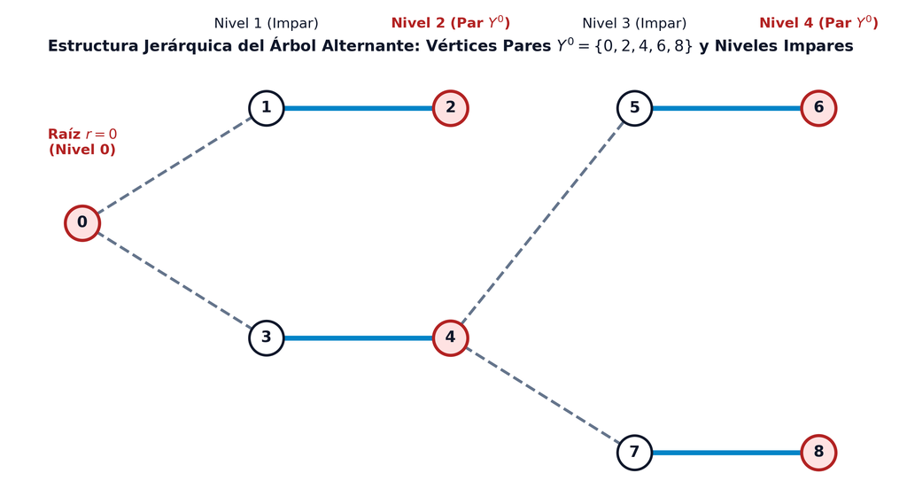

- Árbol alternante con raíz en $r = 0$. Vértices pares $Y^0 = \{0, 2, 4, 6, 8\}$ (en rojo).

## Reglas de exploración desde vértices pares Y0

- **1. Detección de Ciclos Impares (Flores)**:
  - Si existen dos vértices de $Y^0$ conectados por una arista $\{i, j\} \in E$, se detecta un **ciclo impar** (flor). Se contrae en un supernodo $w$.
- **2. Expansión del Árbol hacia $j \notin Y$**:
  - **Hacia adyacente no saturado ($sat(j) = 0$)**: Se detecta una **cadena alternante incremental** entre la raíz y $j$.
  - **Hacia adyacente saturado ($sat(j) = 1$)**: Si $\{j, k\} \in K$, se incorporan $\{i, j\}$ y $\{j, k\}$, añadiendo $k$ a $Y^0$.

## Algoritmo de Flor de Edmonds: Paso A y Paso B

**Esquema: Algoritmo de Flor de Edmonds (Parte 1)**

- **Paso A (Inicialización)**:
  - Encontrar un emparejamiento inicial factible $K$ en $G$ (por ejemplo, $K = \emptyset$).
- **Paso B (Condición de parada elemental)**:
  - Si el número de vértices no saturados por $K$ es $0$ o $1$, **PARAR**: $K$ es de máximo cardinal. En caso contrario, ir al **Paso C**.

## Algoritmo de Flor de Edmonds: Paso C (Casos 1 y 2)

**Esquema: Algoritmo de Flor de Edmonds (Paso C - Casos 1 y 2)**

- **Paso C.1**: Seleccionar una raíz expuesta $i_0 \in V$ ($sat(i_0) = 0$). Inicializar $Y = Y^0 = \{i_0\}$, $T = \emptyset$.
- **Paso C.2 (Exploración desde $Y^0$)**:
  - **Caso 1 (Detección de Flor)**: Si existen $i, j \in Y^0$ con $\{i, j\} \in E$, contraer el ciclo impar $W$ en $G/W$, actualizar $Y$ y $Y^0$ y volver al Paso C.2.
  - **Caso 2 (Extensión del Árbol)**: Si existe $i \in Y^0$ y $j \notin Y$ saturado por $\{j, k\} \in K$ con $\{i, j\} \in E$, incorporar $\{i, j\}$ y $\{j, k\}$ al árbol: $Y \leftarrow Y \cup \{j, k\}$, $Y^0 \leftarrow Y^0 \cup \{k\}$ y volver al Paso C.2.

## Algoritmo de Flor de Edmonds: Paso C (Casos 3 y 4)

**Esquema: Algoritmo de Flor de Edmonds (Paso C - Casos 3 y 4)**

- **Caso 3 (Detección de Cadena Incremental)**:
  - Si existe $i \in Y^0$ y $j \notin Y$ expuesto ($sat(j) = 0$) con $\{i, j\} \in E$, se detecta una **cadena incremental** $\mu$.
  - Realizar la transferencia $K \leftarrow K \bigtriangleup \mu$, descontraer todas las flores activas y volver al **Paso B**.
- **Caso 4 (Árbol Bloqueado / Húngaro)**:
  - Si no es posible aplicar ningún caso desde $Y^0$, fijar $i_0$ como no aumentable. Si quedan raíces sin explorar, ir a C.1; si no, **PARAR**: $K$ es de **máximo cardinal**.

## Ejemplo Edmonds: Traza completa en grafo de 8 nodos

- **Grafo $G=(V, E)$ de 8 vértices y 10 aristas**:
  - $V = \{1, 2, 3, 4, 5, 6, 7, 8\}$.
  - $E = \bigl\{ \{6,7\}, \{7,8\}, \{1,2\}, \{2,3\}, \{3,4\}, \{4,5\}, \{4,6\}, \{1,5\}, \{1,7\}, \{2,8\} \bigr\}$.
- **Fase Inicial**:
  - **Paso A**: $K = \emptyset$. Vértices expuestos: $\{1, 2, 3, 4, 5, 6, 7, 8\}$.
  - **Paso B**: 8 vértices expuestos ($> 1$) $\implies$ Proceder al Paso C.

## Ejemplo Edmonds: Iteración 1 - Estado inicial K0

- **Paso C.1**: Raíz expuesta $i_0 = 1$. $Y = Y^0 = \{1\}$, $T = \emptyset$.
- **Paso C.2**:
  - Para $1 \in Y^0$, vecino expuesto $2 \notin Y$ con $\{1,2\} \in E$ (Caso 3).
  - Cadena incremental: $\mu_1 = (1, 2)$.
- **Transferencia**:
  $$K^1 = \bigl\{ \{1,2\} \bigr\}$$

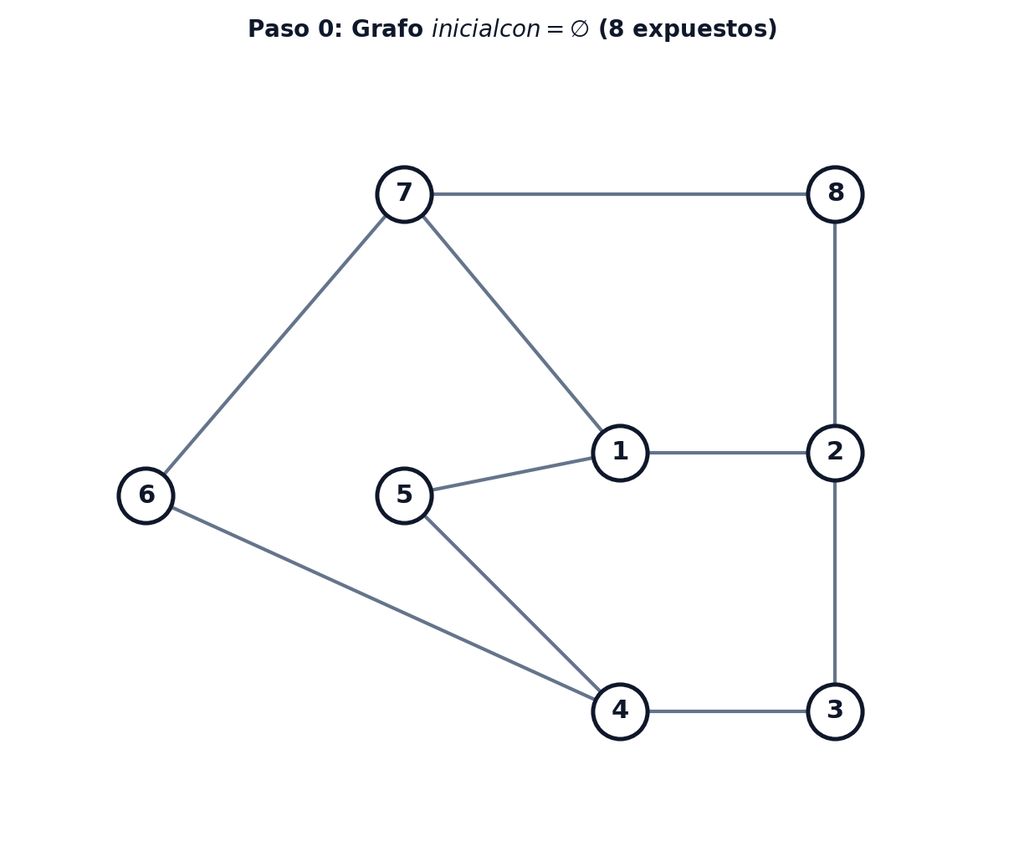

## Ejemplo Edmonds: Iteración 1 - Transferencia a K1

- **Nuevo estado $K^1 = \{\{1, 2\}\}$**:
  - Cardinal $|K^1| = 1$.
  - Vértices saturados: $\{1, 2\}$.
  - Vértices expuestos: $\{3, 4, 5, 6, 7, 8\}$.

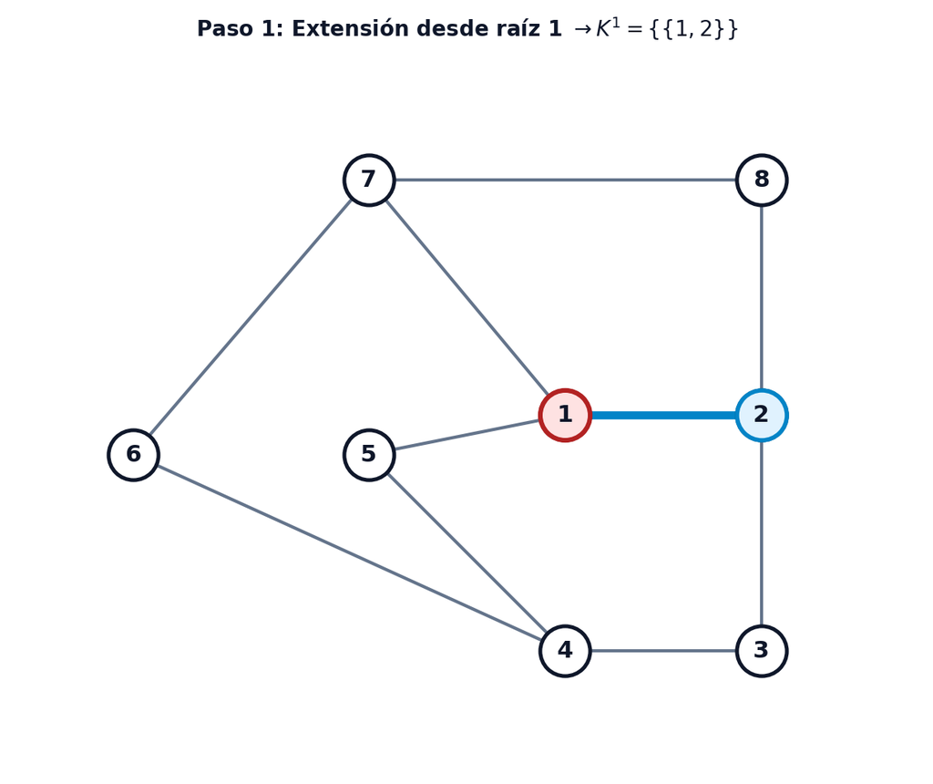

## Ejemplo Edmonds: Iteración 2 - Exploración desde raíz 3

- **Paso B**: 6 expuestos $\implies$ Paso C.
- **Paso C.1**: Raíz expuesta $i_0 = 3$. $Y = Y^0 = \{3\}$.
- **Paso C.2 (Extensión del árbol)**:
  - Vecino saturado $2 \notin Y$ (por $\{1,2\} \in K$).
  - Se incorporan $\{2,3\}$ y $\{1,2\}$:
    $$Y = \{1, 2, 3\}, \quad Y^0 = \{1, 3\}$$

[figure not shown]

## Ejemplo Edmonds: Iteración 2 - Transferencia a K2

- **Detección de cadena incremental**:
  - Desde $3 \in Y^0$, vecino expuesto $4 \notin Y$ con $\{3,4\} \in E$ (Caso 3).
  - Cadena incremental: $\mu_2 = (3, 4)$.
- **Transferencia**:
  $$K^2 = \bigl\{ \{1,2\}, \, \{3,4\} \bigr\} \quad (|K^2| = 2)$$
  - Vértices libres restantes: $\{5, 6, 7, 8\}$.

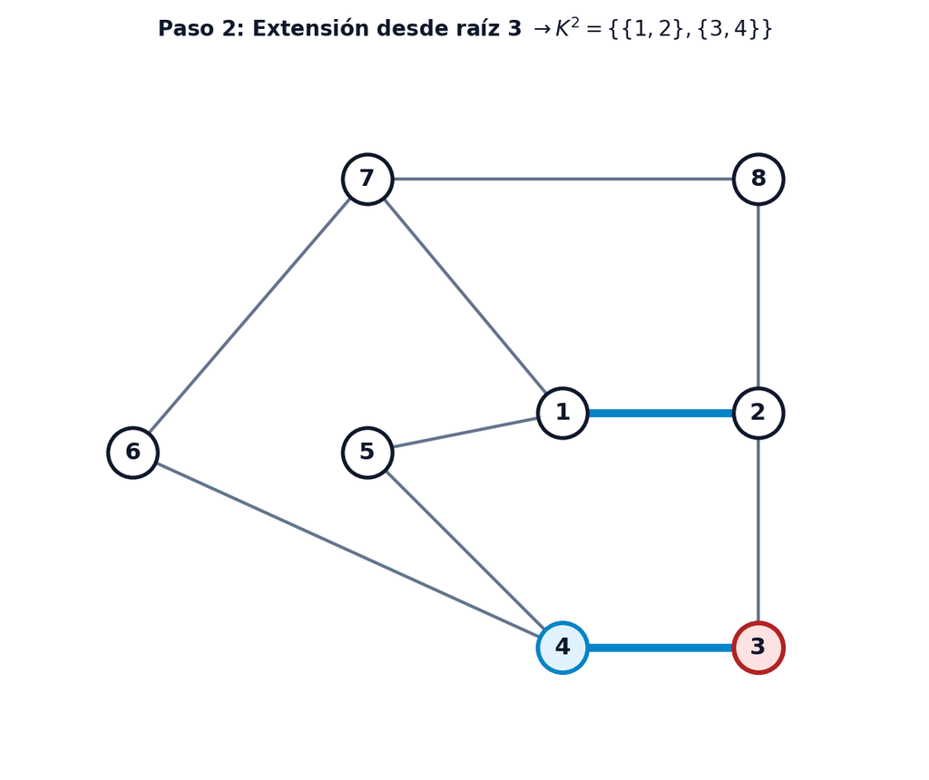

## Ejemplo Edmonds: Iteración 3 - Exploración desde raíz 5

- **Paso B**: 4 expuestos $\{5, 6, 7, 8\}$.
- **Paso C.1**: Raíz expuesta $i_0 = 5$. $Y = Y^0 = \{5\}$.
- **Paso C.2 (Extensiones sucesivas)**:
  - Vecino saturado $1 \implies$ añadir $\{5,1\}$ y $\{1,2\}$.
  - Vecino saturado $4 \implies$ añadir $\{5,4\}$ y $\{4,3\}$.
    $$Y = \{1, 2, 3, 4, 5\}, \quad Y^0 = \{2, 3, 5\}$$

[figure not shown]

## Ejemplo Edmonds: Iteración 3 - Detección de la Flor W

- **Caso 1 (Detección de Flor)**:
  - Entre los nodos pares $Y^0 = \{2, 3, 5\}$, existe la arista $\{2, 3\} \in E$.
  - Se identifica el ciclo impar de 5 vértices:
    $$W = \{1, 2, 3, 4, 5\}$$

[figure not shown]

## Ejemplo Edmonds: Iteración 3 - Contracción al pseudonodo w

- **Contracción de $W$**:
  - Comprimimos $W$ en el pseudonodo $w$.
  - Grafo comprimido $G/W$ con vértices $\{w, 6, 7, 8\}$.
  - Árbol actualizado: $Y = Y^0 = \{w\}$, $K = \emptyset$.
- **Transferencia en $G/W$**:
  - Arista $\{w, 6\}$ a nodo expuesto $6 \implies K = \bigl\{ \{w, 6\} \bigr\}$.

[figure not shown]

## Ejemplo Edmonds: Iteración 4 - Exploración en G/W

- **Paso B en $G/W$**: Expuestos $\{7, 8\}$.
- **Paso C.1**: Raíz $i_0 = 7$. $Y = Y^0 = \{7\}$.
- **Paso C.2 (Extensión)**:
  - Vecino saturado $w \implies$ añadir $\{7,w\}$ y $\{w,6\}$.
    $$Y = \{w, 6, 7\}, \quad Y^0 = \{6, 7\}$$
- **Detección de Segunda Flor**:
  - Arista $\{6, 7\} \in E$ entre pares $\implies W' = \{w, 6, 7\}$.

[figure not shown]

## Ejemplo Edmonds: Fase de Descompresión de W’

- **Segunda contracción y parada**:
  - Comprimir $W'$ en $w'$. Arista $\{w', 8\} \implies K = \bigl\{ \{w', 8\} \bigr\}$.
  - 0 vértices libres en $G/W' \implies$ ¡Parada alcanzada!
- **Descompresión de $W'$**:
  - $\{w', 8\} \to \{7, 8\} \in E$.
  - En $W'$, arista interna $\{w, 6\}$.
    $$K = \bigl\{ \{w, 6\}, \, \{7, 8\} \bigr\} \text{ en } G/W$$

[figure not shown]

## Ejemplo Edmonds: Descompresión de W y Solución Perfecta

- **Descompresión de $W = \{1, 2, 3, 4, 5\}$**:
  - $\{w, 6\} \to \{4, 6\} \in E$.
  - Nodo 4 saturado exteriormente.
  - En $W$, emparejamiento interno $\{1, 5\}$ y $\{2, 3\}$.
- **Emparejamiento Óptimo Final**:
  $$K^* = \bigl\{ \{1, 5\}, \, \{2, 3\}, \, \{4, 6\}, \, \{7, 8\} \bigr\}$$
  - Cardinal $|K^*| = 4$ (**emparejamiento perfecto**).

[figure not shown]

## Ejemplo Edmonds: Animación de la traza completa

[interactive chart not shown]

## Complejidad y síntesis del Algoritmo de Edmonds

- **Complejidad polinomial**:
  - Búsqueda por árbol y contracciones: $\mathcal{O}(|V|^2 |E|)$ o $\mathcal{O}(|E|\sqrt{|V|})$ con estructuras avanzadas.
  - Pertenece estrictamente a la clase de complejidad **P**.
- **Síntesis metodológica**:
  1. Construir árboles alternantes desde raíces expuestas.
  2. Contraer ciclos impares (flores) entre nodos pares $Y^0$.
  3. Transferir al hallar vértices expuestos y descomprimir flores.

# Problemas de recubrimiento en grafos y relaciones de dualidad

## Ejemplo: Vigilancia de murallas en la fortaleza

- **Recinto de 12 torres**: Cada guardia asignado a una muralla $\{u, v\}$ vigila las dos torres extremas ($u$ y $v$).
- **Objetivo**: Hallar el **número mínimo de guardias** necesarios para que **todas las torres queden vigiladas**.

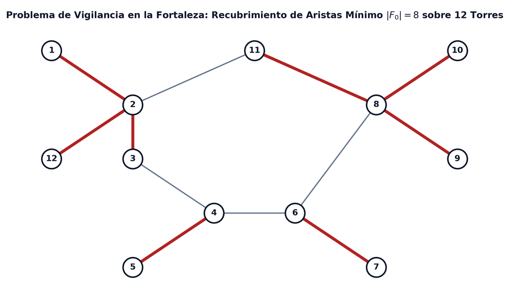

## Ejemplo: Solución de recubrimiento mínimo en la fortaleza

- **Modelo como recubrimiento de aristas $F \subseteq E$**:
  - Todo vértice $v \in V$ debe ser incidente en al menos una arista de $F$ ($\sum x_e \ge 1$).
- **Selección óptima de 8 aristas (en rojo)**:
  $$F_0 = \bigl\{ \{1,2\}, \, \{2,12\}, \, \{2,3\}, \, \{4,5\}, \, \{6,7\}, \, \{8,9\}, \, \{8,10\}, \, \{8,11\} \bigr\}$$
- **Resultado**:
  - Se cubren las 12 torres con $|F_0| = 8$ guardias a coste mínimo.

## Definición: Recubrimiento de aristas (Edge Cover)

**Recubrimiento de aristas (Edge Cover)**

Dado un grafo no dirigido $G = (V, E)$ sin vértices aislados, un **recubrimiento de aristas** (o *edge cover*) es un subconjunto de aristas $F \subseteq E$ tal que todo vértice $v \in V$ es incidente en al menos una arista de $F$:

$$\bigcup_{e \in F} e = V$$

- **Condición de existencia**: Requiere que $G$ no contenga vértices aislados ($\operatorname{gr}(v) \ge 1, \; \forall v \in V$).

## Monotonía del recubrimiento

**Monotonía del recubrimiento**

Dado un grafo $G = (V, E)$ y un recubrimiento de aristas $F \subseteq E$, si $F' \subseteq E$ satisface $F \subseteq F'$, entonces $F'$ es también un recubrimiento de aristas de $G$.

- **Contraste dual con emparejamientos**:
  - **Emparejamientos**: Hereditarios hacia abajo ($K' \subseteq K \implies K'$ emparejamiento).
  - **Recubrimientos**: Monótonos crecientes hacia arriba ($F \subseteq F' \implies F'$ recubrimiento).

## Teorema: Dualidad de Gallai para emparejamientos y recubrimientos

**Dualidad de Gallai para emparejamientos y recubrimientos (1959)**

Sea $G = (V, E)$ un grafo simple conexo con $n = |V|$ vértices y sin nodos aislados. Sean $K_0 \subseteq E$ un emparejamiento de **máximo cardinal** y $F_0 \subseteq E$ un recubrimiento de aristas de **mínimo cardinal**. Entonces se verifica la identidad exacta:

$$|K_0| + |F_0| = n$$

## Construcción del recubrimiento mínimo F1 a partir de K0

- **Algoritmo constructivo directo**:
  1. Obtener el emparejamiento de máximo cardinal $K_0$.
  2. $K_0$ satura a $2|K_0|$ vértices, dejando $n - 2|K_0|$ vértices expuestos.
  3. Añadir una arista incidente $e_v \in E$ para cada vértice expuesto $v \notin V(K_0)$:
     $$F_1 = K_0 \cup \bigl\{ e_v \in E \mid v \in V \setminus V(K_0) \bigr\}$$
- **Cardinal mínimo**: $|F_1| = |K_0| + (n - 2|K_0|) = n - |K_0| \implies |K_0| + |F_1| = n$.

## Construcción del emparejamiento máximo K1 a partir de F0

- **Algoritmo constructivo recíproco**:
  1. Sea $F_0$ un recubrimiento de aristas de mínimo cardinal.
  2. El subgrafo $(V, F_0)$ está formado exclusivamente por estrellas conexas (árboles de profundidad 1).
  3. Para cada estrella con $k \ge 2$ aristas, eliminar $k - 1$ aristas redundantes, conservando una única arista por componente:
     $$K_1 = F_0 \setminus \bigl\{ \text{aristas sobrantes en vértices de grado } > 1 \text{ en } F_0 \bigr\}$$
  4. $K_1$ es un **emparejamiento de máximo cardinal** ($|K_1| = |K_0|$).

## Significado combinatorio: Relación de conservación de Gallai

- **Dualidad entre Packing y Covering**:
  - Cada arista de un emparejamiento satura a $2$ vértices distintos.
  - Cada arista adicional de un recubrimiento cubre a $1$ vértice libre.
- **Conservación estructural**:
  - El déficit de aristas en el emparejamiento respecto del total de nodos se traduce exactamente en el superávit de aristas requeridas para el recubrimiento mínimo.

## Ejemplo: Ilustración de la Dualidad de Gallai en 11 vértices

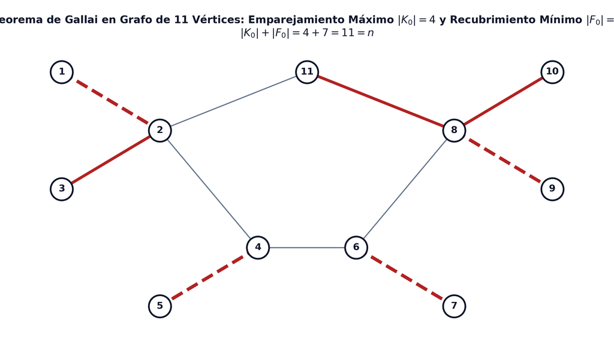

# Emparejamiento de máximo peso y algoritmo primal-dual

## Definición: Problema de emparejamiento de máximo peso

**Problema de emparejamiento de máximo peso**

Dado un grafo simple no dirigido $G = (V, E)$ y un vector de pesos $\mathbf{p} = \{p(e) \mid e \in E\}$, el **problema de emparejamiento de máximo peso** consiste en determinar un emparejamiento $K \subseteq E$ que maximice:

$$p(K) = \sum_{e \in K} p(e)$$

- **Ponderación vs Cardinalidad**:
  - Un emparejamiento óptimo en peso no tiene por qué saturar el mayor número de vértices si aristas individuales concentran pesos superiores.

## Definición: Coste reducido de una cadena alternante

**Coste reducido de una cadena alternante**

Dado un grafo $G = (V, E)$ con pesos $p(e)$, un emparejamiento $K \subseteq E$ y una cadena alternante $L$, se define el **coste reducido** de $L$ respecto de $K$, denotado por $\delta_L$, como:

$$\delta_L = p(L \cap \overline{K}) - p(L \cap K) = \sum_{e \in L \setminus K} p(e) - \sum_{e \in L \cap K} p(e)$$

donde $\overline{K} = E \setminus K$.

## Definición: Ciclo alternante y signo del coste reducido

**Ciclo alternante**

Dado un grafo $G = (V, E)$ y un emparejamiento $K \subseteq E$, un **ciclo alternante** es una cadena alternante cerrada y simple de longitud estrictamente par, cuyas aristas pertenecen y no pertenecen alternativamente a $K$.

- **Impacto económico**:
  - Si $\delta_L > 0$, la transferencia incrementa el peso: $p(K') = p(K) + \delta_L$.
  - Si $\delta_L = 0$, mantiene invariable el peso acumulado.

## Teorema: Optimalidad por costes reducidos

**Optimalidad por costes reducidos**

Dado un grafo $G = (V, E)$ con pesos $p(e)$ sobre las aristas, un emparejamiento $K \subseteq E$ es de **máximo peso** si y solo si **no existe ninguna cadena alternante** (abierta o cerrada) con coste reducido estrictamente positivo ($\delta_L \le 0$ para toda cadena alternante $L$).

- **Generalización de Berge**:
  - Cardinal: Cadenas incrementales (ganancia $+1$ arista).
  - Ponderado: Cadenas con ganancia neta de peso positiva ($\delta_L > 0$).

## Algoritmo de aumento por cardinalidad fija

- **Construcción inductiva por cardinalidades $m = 1, 2, \dots, \lfloor n/2 \rfloor$**:
  - **$K^1$**: Arista individual de mayor peso en $E$.
  - **$K^2$**: Par de aristas disjuntas de mayor suma de pesos en $E$.
  - **$K^{m+1}$**: Se obtiene inductivamente a partir de $K^m$ mediante transferencias de coste reducido máximo.

## Teorema: Progresión de emparejamientos de peso máximo

**Progresión de emparejamientos de peso máximo**

Sea $G = (V, E)$ un grafo, sea $K^m$ el emparejamiento de máximo peso entre todos los de cardinal $m$, y sea $L$ una **cadena alternante incremental** respecto de $K^m$ que posea el **coste reducido máximo** ($\delta(L) = \max \delta$).

Entonces, el emparejamiento $K^{m+1} = K^m \bigtriangleup L$ obtenido por la transferencia de $L$ es el **emparejamiento de máximo peso entre todos los de cardinal $m + 1$**.

## Ejemplo: Emparejamiento de peso máximo en grafo de 6 nodos

- **Grafo ponderado de 6 vértices y 9 aristas**:
  $$\begin{aligned}
  & p(4,5)=5, \quad p(3,4)=4, \quad p(2,3)=3, \quad p(6,3)=3, \quad p(6,5)=2, \\
  & p(1,2)=2, \quad p(6,2)=2, \quad p(1,6)=1, \quad p(2,4)=1
  \end{aligned}$$
- **Objetivo algorítmico**: Determinar inductivamente la sucesión de emparejamientos óptimos $K^1, K^2, K^3$.

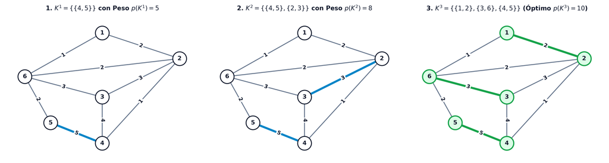

## Ejemplo Peso Máximo: Paso 1 (Cardinal m = 1)

- **Arista de peso máximo**:
  $$e^* = \{4, 5\} \quad \text{con } p(4, 5) = 5$$
- **Emparejamiento $K^1$**:
  $$K^1 = \bigl\{ \{4, 5\} \bigr\}, \quad p(K^1) = 5$$
- **Vértices expuestos**: $\{1, 2, 3, 6\}$.

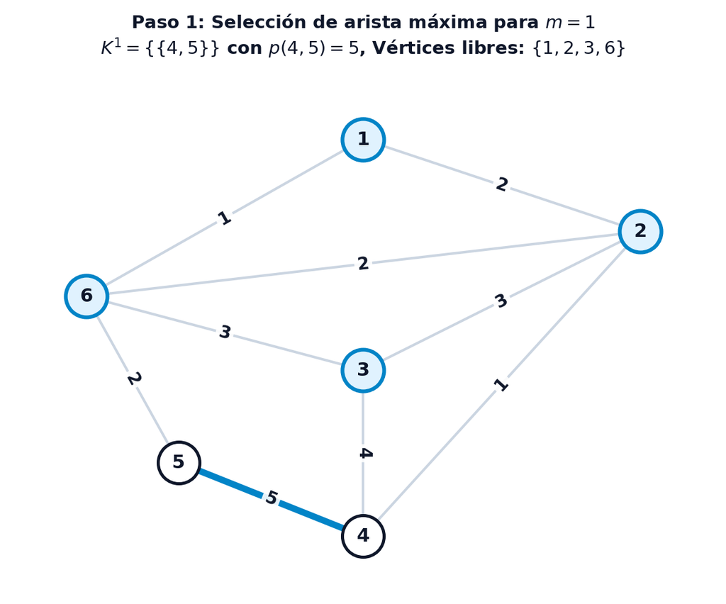

## Ejemplo Peso Máximo: Paso 2a - Búsqueda de aumento para m = 2

- **Evaluación de aristas disjuntas a $\{4,5\}$**:
  - $\{2, 3\}$: $\delta = p(2, 3) = 3$.
  - $\{6, 3\}$: $\delta = p(6, 3) = 3$.
  - $\{1, 2\}$: $\delta = p(1, 2) = 2$.
- **Selección de la arista óptima**:
  - Se selecciona $L_1 = \{2, 3\}$ con incremento máximo $\delta(L_1) = 3$.

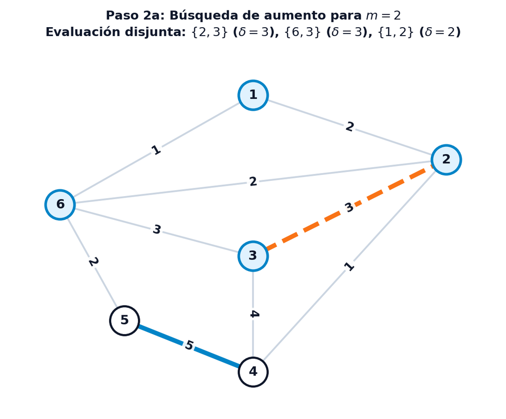

## Ejemplo Peso Máximo: Paso 2b - Transferencia a K2

- **Nuevo estado $K^2$**:
  $$K^2 = K^1 \cup \bigl\{ \{2, 3\} \bigr\} = \bigl\{ \{4, 5\}, \, \{2, 3\} \bigr\}$$
  $$p(K^2) = 5 + 3 = 8$$
- **Vértices expuestos restantes**:
  - Vértices libres: $\{1, 6\}$.

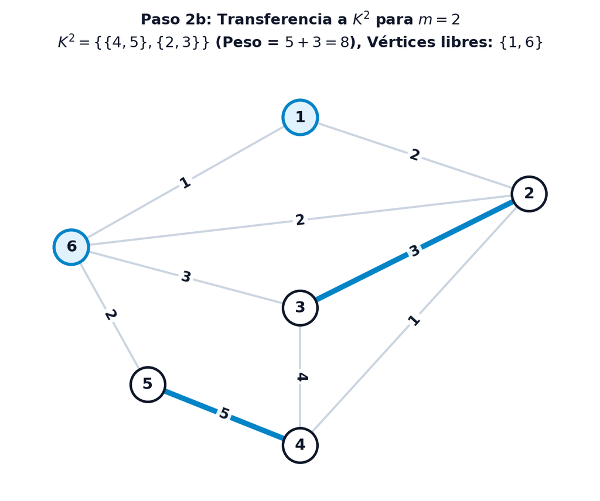

## Ejemplo Peso Máximo: Paso 3a - Evaluación de cadenas para m = 3

- **Cadenas entre expuestos 1 y 6**:
  1. $L_A = 1 - 6$: $\delta = p(1, 6) = 1$.
  2. **$L_B = 1 - 2 - 3 - 6$**:
     $$\delta(L_B) = (2 + 3) - 3 = \mathbf{2}$$
  3. $L_C = 1 - 2 - 3 - 4 - 5 - 6$:
     $$\delta(L_C) = (2 + 4 + 2) - (3 + 5) = \mathbf{0}$$
- **Selección de la cadena máxima**:
  - Cadena de ganancia máxima: **$L_B$** ($\delta = 2$).

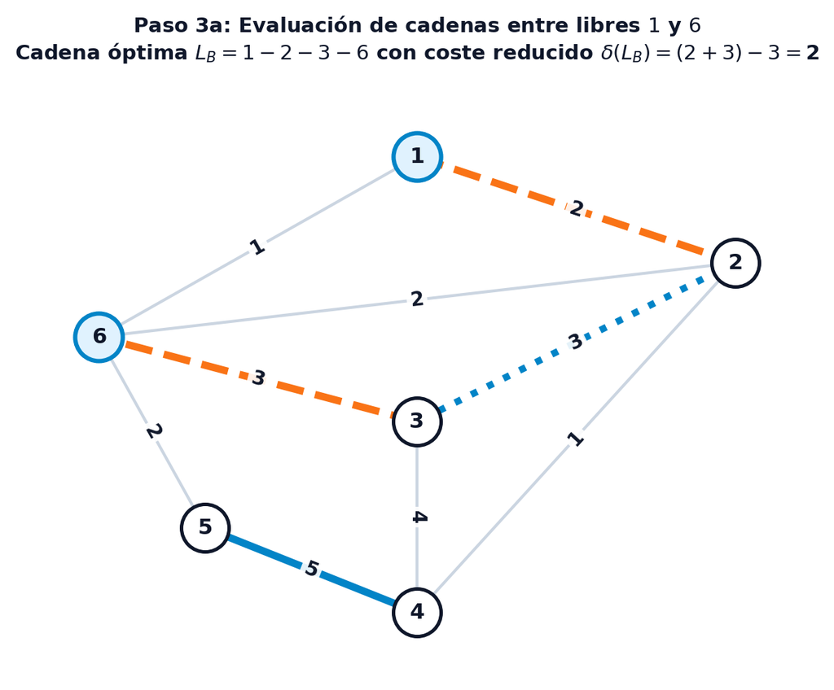

## Ejemplo Peso Máximo: Paso 3b - Transferencia a K3 y Solución Óptima

- **Transferencia $K^3 = K^2 \bigtriangleup (1-2-3-6)$**:
  - Entran $\{1, 2\}$ y $\{3, 6\}$; sale $\{2, 3\}$.
    $$K^3 = \bigl\{ \{1, 2\}, \, \{3, 6\}, \, \{4, 5\} \bigr\}$$
    $$p(K^3) = p(K^2) + \delta(L_B) = 8 + 2 = \mathbf{10}$$
- **Optimalidad global absoluta**:
  - $K^3$ es **perfecto** y de **máximo peso global**.

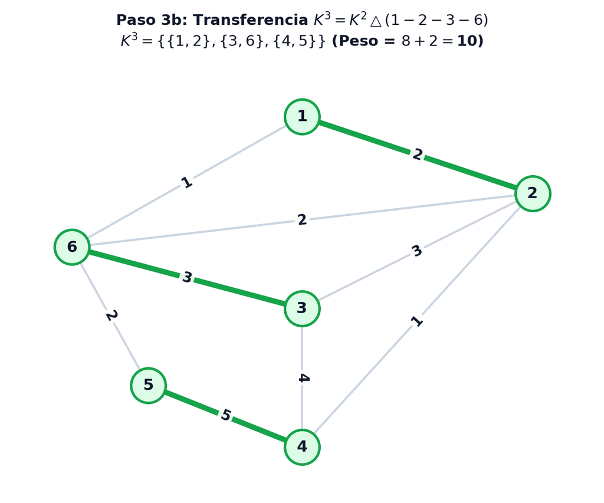

## Ejemplo Peso Máximo: Animación de la traza completa

[interactive chart not shown]

## Resumen de la traza y síntesis del Tema 9

- **Evolución por cardinalidades**:

| Cardinal $m$ | Emparejamiento óptimo $K^m$ | Cadena aplicada $\mu^*$ | Ganancia $\delta$ | Peso Total $p(K^m)$ |
| --- | --- | --- | --- | --- |
| **$m = 1$** | $\{\{4, 5\}\}$ | Arista máxima $\{4, 5\}$ | $+5$ | **5** |
| **$m = 2$** | $\{\{4, 5\}, \{2, 3\}\}$ | $\{2, 3\}$ | $+3$ | **8** |
| **$m = 3$** | $\{\{1, 2\}, \{3, 6\}, \{4, 5\}\}$ | $1 - 2 - 3 - 6$ | $+2$ | **10** |

- **Conclusiones del capítulo**:
  - **Berge**: Ausencia de cadenas incrementales $\iff$ Máximo cardinal.
  - **Edmonds**: Contracción de flores para grafos generales en tiempo polinomial.
  - **Gallai**: Identidad exacta $|K_0| + |F_0| = n$.
  - **Pesos**: Progresión inductiva por costes reducidos $\delta_L$.